# 4 価値について再考する：実践の諸システム間の多様性および正義

第3章で検討した例のいずれにおいても、研究の状況には互いに異なることがありうる点、生み出される知識の内容と質に直接関連する点のいくつかが示されている。こうした差異を認識論的多様性と以降呼ぶことにするが、私はこれを、知識の発展・理解、および／ないし、成立に影響を及ぼす諸々の仕方で異なっていたり多様であったりする状態や事実のことと定義する[^1]。本章では研究実践のひとつのシステム内でどのように管理されているかを含め、認識論的多様性を考慮することは、（1）科学がどのように機能するかを理解するうえで不可欠である、（2）認識論的な（不）正義に関する特定の解釈と不可分に結びついている、（3）OSを概念化し実装するどのような取り組みでも開始点となり、それなしには研究の質と透明性に対するOSの願望は満たされないことを主張する。

## 4.1 認識論的多様性と実践の諸システム

議論の第一歩は、OSの諸々の原則・ツールの実装に関わるさまざまな要素と、特定の状況内での科学的探究においてそのような要素がクラスター化され整えられるさまざまな仕方について言及することとなる。第3章の例は、研究の実現性についての諸条件だけでなく、諸々の手順・結果を評価する規準を決定づけるうえで、表2にあげたようなインフラ・制度・社会文化底な要因が果たす重要な役割を浮き彫りにしていた。この点は強調されるべきで、というのもこれらの要因のいくつかは必ずしも認識論的な意義があるとはみなされないためである。哲学者の中には、研究の概念的・方法論的な構成要素は制度的な設定やインフラといった社会的・物質的要素から切り離して考察・評価できると考えるものもいる。それに対して第3章で述べたOSを実装しようとする試みは、従来、科学的に直接的な含意をもつと考えられてきた要素（理論や方法など）と、研究にとって「外部」または「付属的」とみなされることもある要素（地理的位置、知的財産制度、行政支援など）との相互依存関係を示すものだと私は考える。ヘレン・ロンジーノ、アリソン・ワイリー、ヘザー・ダグラス、ミリアム・ソロモンなどこの問題に長年取り組んできた研究者の足跡をたどりながら、まさに研究を特徴づけるのは高レベルの認識論的多様性であるからこそ、内的要因か外的要因かを厳密に区別することには問題があると私は主張する。むしろこのような区別は、調査のどの段階においても所与の研究環境のどの側面が科学的な目的・方法・成果に影響を与えているかという状況理解を通じてケースバイケースでなされなければならない[^2]。

表2. OSに関連する認識論的多様性の源（概念・物質・方法論・インフラ・社会文化・制度の6カテゴリーに分類）

概念

- 理論的観点
- 背景となる前提

物質

- 対象オブジェクト
- 資材
- 来歴

方法論

- 手法およびモデル化ツール
- 標準：形式および意味論

インフラ

- 財政レベルおよび制約
- 情報通信技術とその他のデジタル技術
- 公表および交換の場
- 移動および交通
- 資金源および関連コミットメント

社会文化

- 研究評価システム（地域・国内・国際）
- 法的および倫理的な結果責任
- 地政学的な位置づけ
- 価値および目的
- 言語
- 研究者の人口統計学的特性（ジェンダー、階級、 エスニシティ、年齢、身体能力）

制度

- キャリア段階
- 力関係
- 制度上および管理上の支援
- 研究領野と関連規範
- 知的財産制度

この議論と密接に関連しているのは、学問分野の諸々の境界が科学研究における認識論的多様性を示す唯一の、いやおそらくは主要な指標でさえないという観察である。学問分野が知識生成の不可欠な単位であり続け、特定クラスターの理論的・制度的・方法論的選好が用いられることを要求・正当化するうえで重要な役割を担っていることに疑いの余地はない（Mäki et al. 2018）。だが分野の伝統を参照するだけでは、同じ学問分野内でも、異なる条件下で異なる問題に取り組んでいる研究者が、何がベストプラクティスを構成し誰がそれを裁定する責任を負うのかにということついては大きく異なる認識をもつ場合があるという局所的なばらつきによって証明されるように、認識論的多様性の毛細管現象的で高度に状況化された性質をとらえるには不十分である（Leonelli 2012, Gerson 2013, Levin et al.）。さらに、学問的な訓練や場所に訴えたところで、研究者がある探究に立ち向かう際には自身らの仕事を多様な仕方で整理する場合があることを必ずしもとらえきれていない（Andersen 2016, Nersessian 2022）。気候変動・パンデミック・人口増加といった全体的な課題に立ち向かうことを目的とした学際的・分野横断的な研究の取り組みが世界的に増加していることに鑑みると、このことは特に注目に値する。そうした複数の観点からなるプロジェクトでOSとその実装における認識論的多様性が果たす役割を理解するということは、「学問分野」「領域」あるいは「領野」というおおまかなカテゴリでは提供できない、諸々の研究アプローチ間の差異をよりきめ細かく分析することと関連してくる。この目論見を達成するために、私はハソク・チャンの「実践のシステム」という考え方を導入する。これは、“ある諸目的を達成することを視野に入れてなされる認識論的活動の一貫性ある集合”（Chang 2013, 16）を意味する[^3]。このように位置づけられた科学的活動では、ある時点における研究のパフォーマンスと、特定の目的を追求するために探究が構造化・実行される諸々の仕方——それは狭いこともあれば広いこともあり、静的なものでもあれば変わりうるものでもあり、広く共有されることもあれば少数により特権化されていることもある——に焦点が当てられる。このアプローチの幅の広さと柔軟さは、「学問分野」のような当然とされ制度化されたカテゴリを超えて、「異なっていたり多様であったりする状態や事実」、そしてそうした差異を認識論的に際立たせるもの（認識論的多様性に関する私の定義にあるように「知識の発展および／ないし理解に影響を及ぼす」もの）についてのきめ細かな分析を容易にする。ここでは、科学の多元主義に関する現在の哲学的研究にもとづき、認識論的多様性を損なわせるのではなく、むしろその価値を定めるような仕方でOSを概念化・実装するのに役立つ実践の諸システムについて4つの特徴を論じる。

### 実践の諸システムはローカルな状況・目的・対象に特有である

第一に、チャンの定義から明らかなように、実践の諸システムはそのローカルな状況・対象・目的の特異性においてそれぞれ異なる。研究の戦略・ツールは、最善を尽くし時間をかけて繰り返し改善されていくことで、調査下の現象の諸特徴にあうよう精巧に調整される。つまり、諸々の手法・理論・モデルは研究対象に適合するかどうか（Mitchell 2003）、その対象を例証する資材が利用できるかどうか（Wylie 2003）ということに応じて異なってくる。たとえば鮮新・更新世におけるヒトの化石がもっとも豊富にある場所のひとつ、南アフリカの人類化石遺跡群の遺骨を利用できない古生物学者は、アウストラロピテクス・セディバのようなホモサピエンスの祖先について調査することはできないだろう。そうした資材へアクセスできるようになれば、人類の祖先に関する既存の理解を新しい発見に合致するような形で研究者は修正を迫られることになると思われる。アフリカ南部や東部の遺跡から新たなヒト [humaninがタイポか要確認] の遺骨が続々と発見され、それに伴い遺骨を分析する諸々の技術も進歩するにつれ、研究者が問う内容も変化していくだろうし、それらの問いを探るために必要な諸々の技術や専門知も、中心的な調査対象とされる現象そのものとともに、変化していくだろう（Currie 2018）。研究者は進行中の調査の過程で研究対象を発見したり変更したりするが、同じような状況が、ほとんどの領域、特に往々にして予測不能な仕方で発達・進化・社会化する生命体の研究を中心とする領域において、それら研究の課題および戦略を特徴づける。私たちのダイナミックでプロセス的な世界をもっともよく研究するためには（Dupré and Leonelli 2022）、対象の本質的な不安定性に対して、実践の諸システムは問題指向で（Love 2008）、適応的（McLeod and Nersessian 2013)、反応的なものである必要がある（Feest 2019, Massimi 2022）。これらの要件は、安定性のある研究対象や予見可能な目標を想定し、ベストプラクティスを構成する望ましい要素として一般化可能なアプローチや標準的手法を促す傾向をもつOSと緊張関係にある。諸々の知見や資源を共有したり比較したりすることを可能にするという点において標準化が有効であるように、ローカルな研究設定におけるシステム固有の諸特性——これら諸特性により、調査下にある世界の諸部分の変化によりローカルな研究設定が影響を受けやすくなる——の価値に照らして調整がなされる必要がある。

### 実践の諸システムは諸々のレパートリーにおいてさまざまな程度で定着している

時の経過とともに、いくつかの実践の諸システムは、他のシステムよりも信頼性が高く、動員しやすく、および／ないし生産性が高いという評判をえている。これは、目的を達成するうえで有効か、手法は頑健か、既存の方針や制度的な状況に適しているかといったことに起因するだろう。問題となっている現象の研究に関連する諸々の価値観・信念・制度・方法・目的のまとまりを含むそうした実践の諸システムは、したがって諸現象に関する研究の「絶対的基準」として定着する可能性がある（Caporael et al. 2013）。場合によっては、その結果、ある実践システムはそれ自体が研究領野として制度化されていくことになる。また、実践の諸システムはアンケニーら（Ankeny and Leonelli 2016）が*レパートリー*と呼ぶものになる。これは、必ずしも学問分野の境界線に沿ったものではないが、容易に広く採用することができ、有効で信頼できるものと暗黙のうちに認識されている青写真として強い影響力を保持している科学のやり方のことである[^4]。第3章で見たが、再現性を概念化し評価する際の模範としてランダム化比較試験がとりあげられるのはその格好の例である。データ集約型の作物科学が、ゲノムの配列解読技術に頼るとともに高収量品種の特定に注力し、精密農業に役立つように組み立てられていることがもうひとつ別の例となる。

原理的には、すぐれた研究実践とは所与の問いや対象を調査するのにもっとも適した実践システムが何になりうるかを（そのようなシステムがすでに存在するか、ゼロから開発する必要があるかは別として）自由に検討できることと絡むと主張することができる。実際には、そのような自由が存在することはほとんどない。既存のレパートリーを再展開しようとする強い動機があり、それは特に、そうした成熟した実践の諸システムが標準化された構造（十分に開発されたOSインフラを含む）をもち、新しいシステムを構築するよりも労力が少なくて済む傾向にあるためである。たとえばプロプライエタリなソフトウェアや高性能の配列解読装置が目下の研究の信頼性や質を示す代わりとなるものとして認識されるように、往々にしてレパートリーは科学的な「成功」なるものを定義し、「ベストプラクティス」に対する理解を方向づけることになる。これは、研究者がより多くの成果をあげるほど、より多くの注目を集めるようになるという観察結果を説明づける——この現象はマートンが「マタイ効果」と名づけ、“相当な評価をえている科学者には特定の貢献に対してより大きな評価が与えられていき、まだ実績をあげていない科学者にはそのような評価が与えられないこと” と定義したものである（Merton 1968, 57）。マートンはマタイ効果と制度的に一流の科学者と認められる個人の数が限られていることとの関係を際立たせた。（悪名高い）ノーベル賞の場合のように、選ばれた少数の人々の運が指数関数的に上昇する一方で、同じくらい立派な候補者は相対的に無名の扱いのままとされる傾向にある[^5]。レパートリーに着目することで、この効果に対する相補的な説明を浮き彫りにする。誰かのアプローチがベストプラクティスの模範として認知されるようになると、その認知は（たとえば賞や助成金という形で）権力や諸資源を増大させる傾向があり、その結果、ほかの人々が採用し遂行するレパートリーとして、その実践システムを保持する力がさらに強化されていく[^6]。

研究をおこなったり評価したりする際の諸基準がより広範なレパートリーの中にどのくらい組み込まれているかは、OSと大いに関係がある。レパートリーはいくつかの実践の諸システムにとって重要な足場となり、その結果、その領域で研究とみなされるものの定義や理解そのものにおいてレパートリーの諸側面が定着していく可能性がある。これには、どの手法・目的・専門知が支持・称賛されるかに対して重要な認識論的影響が及ぶことも伴う。実際、私が強調したい第二の特徴は、実践の諸システムは*既存のレパートリー内で定着している*度合いが異なるということであり、したがって研究者が対象とするものに特有な実践の諸システムを自由に選び開発できる度合いも異なるということである。

### 実践の諸システムは新参者に対する透過性が異なる

実践の諸システムは特有なものであり定着しているものであるわけだが、これらを合わせて考えると、OSにとって問題となる。データやソフトウェアを含む既存の諸資源を標準化し再配備することがOSにとっての優先事項である。特に共有することとしてオープン性を解釈する場合、研究の実践とコミュニケーションを改善するための基盤となる一歩として、透明性と自由なアクセスが優先されることになる。しかし標準化および再配備を追求するのであれば、実践の諸システムの特異性と認識論的多様性が失われる道を歩むということにもなる。既存のレパートリー内で定着しているシステムに従い活動している研究者は、そのレパートリーの一部にない要素には価値を見出さないかもしれないし、検討すらしないかもしれない。また、レパートリーを修正しようと思っても、否定的なレビュー、資金提供団体からの拒絶、力をもつ同僚からの批判的な疑義といった形で、研究者は大きなハードルに直面する可能性がある。もちろん、新しい手法の検証や新しいアイデアの裏づけのために、新たな提案に批判が向けられるのは往々にして必要なこととなる。しかしすでに確立されたレパートリーを修正することは、常に急進的なイノベーションの問題というわけではなく、むしろすでに試され検証されてはいるもののまだ広く認知されていない研究のやり方を認めることなのである。たとえば第3章で見たように、特定の場所で特有の植物変異体を栽培することの長期的な生態学的影響を考察することを含め、農業多様性に関する研究は長い間、作物科学の重要な要素として認識されてはきたが、この領域におけるデータ連結のインフラ構築という点では主導的な役割を果たしてこなかった。現在では環境影響に関する情報を取り込むため、既存のデータシステムを修正しようとする科学的な取り組みが盛んになされているものの、現状の農業開発に関する実践の諸システムや関連する見方では遺伝情報が中核とされ、説得力をもつものとして重要視されているが、この作業の障壁となっている。

このことは、研究レパートリーが日常的な研究の遂行時に規範的な推力を相当程度与えていることを物語っている。ジョセフ・ラウズが研究の諸システムに関する代表的な論考で指摘したように、“実践とは、その構成要素の根底にある一定不変なものではなく、結果に対する双務的責任を表すそれら要素間の相互作用のパターンである”（Rouse 2002, 48）。いいかえれば、研究実践のあらゆる諸システムは、特定の種類の規範性を推奨し安定させる。レパートリーの場合は、それが長期間にわたり参加者間のコミュニケーションおよび共同作業の基礎となる。これは新規性を管理し、どの修正が既存のシステムに適合するかしないかを判断するための具体的な戦略を伴うが、当該レパートリーの特有な仕方に有効かどうか整合しているかどうかという点で極めて重要となる。研究の特性について私がここで強調したい第3の点は次となる。実践の諸システムは（それらがアイデアであれ、手法であれ、人であれ、技術であれ、研究拠点であれ）、認識論的に関連性の高い新参者に対する透過性がどのように定義され管理されているかという点で異なっており、保守的なアプローチはOSが提唱するオープン性と包摂性に独特の課題を突きつける。

### 実践の諸システムは個別の境界戦略に基礎づけられている

この点が私を第4および第5の点に向かわせる。それは、研究結果を科学的な貢献と確実にみなすことができるかどうかを判断するために、ある実践システムの中で用いられている境界戦略に関するものである。そして、そのような決定に誰が関与すべきなのかというものである。境界戦略が暗黙のうちに想定されているにせよ、明示的に議論されているにせよ、研究者によるそうした戦略の策定・採用は、そもそも研究の実践システムを生み出し維持管理するうえで避けられない部分である。研究実践の諸システムとは、境界を設定することおよび排除することのシステムである。何が適切な科学で何がそうでないか、どのような形の専門知が適切であるとみなされるかといった規準を設定することで、境界戦略は認識論的活動をまとめあげ、それを維持する接着剤となる——チャンの表現では、実践の諸システムを首尾一貫したものにすること、アンケニーやレオネッリの表現では、レパートリーを安定した状態に保つこととなる[^7]。これはカール・ポパーとトーマス・クーンの両者が指摘していたことでよく知られているが、クーンのパラダイムという考えは大規模で通約不可能な変化を主張するものであり、きめ細かく、状況に埋め込まれていて、動的な境界の性質をうまくとらえることができていない。ポパーは科学と疑似科学の境界を反証という普遍的な仕組みに基礎づけ、概念的および方法論的な要因以外の規範的要因の関連性を否定した——これは不幸な選択であって、多くのあるいはほとんどの研究の取り組みは大胆な仮説を裏づける、ないし反証するための試みではないし、反証を構成するものは絶望的に不十分なままとなっている（Hesse 1974, Lakatos 1978）。

クーンやポパーが境界の問題を取り上げたのとは対照的に、私がいう実践の諸システムの議論では、*特定の条件や目的が与えられた場合*に、何がある実践システムの一部となるべきか否かをめぐり状況に埋め込まれた判断をくだすということの認識論的重要性を強調することが意図されている。OS運動を支えるものも含め、「ベストプラクティス」のために諸々の一般的な原則や手順を無差別に訴えても、現場の研究戦略やシステム上に容易には写像されない。ある実践システムが長期にわたって信頼できる知識を生み出すためには、研究者らの変容する環境・理解・動機の変化に適応できないといけないし、同様の目的をもち、および／ないし、同様の設定を伴うその他の実践の諸システムによりなされた選択を評価・比較できなければならない（Gerson 2013）。したがって、ある所与のシステムの境界戦略を反復的に見直すことは、すぐれた科学実践の部分・区画となる。また一般化や標準化により、実践の諸システムは比較しやすくなり、さらには同じ広範なレパートリーの部分として諸システムを照合しやすくなる一方、それらは将来的な調査にとって顕著なことが判明するかもしれないシステム固有の差異を不明瞭なものにする傾向もある[^8]。リチャード・レビンズが生物学的モデルについて述べたように（Levins 1966）、一般性・現実性・精確性の間には避けられないトレードオフがあり、特に一般化可能なツール・手法・主張が通常は認識論的に重視されることを考慮すると、このトレードオフは注意深く監視される必要がある。

今日の科学界は、絶望的なまでに断片化され過度に専門化された知識の総体を接続・統合し、おそらく統一さえする方法を模索しており、したがって諸々の知見を集積・統合する集合的な取り組みとしての発見モデルを支持している。オープンサイエンス政策ではそうした取り組みを支持する仕方で共同作業の強化を約束している。こうした探究は、関連する認識論的なコストおよび損失が意識され続けていて、目下のシステムに属するものか属さないものかを判断するのに用いられる何らかの規準、つまり研究において許容される仕方と認められるものか否かを基礎づける排他的な論理を、定期的・批判的に評価する仕組みが整っている場合にのみ擁護可能である。したがって何らかの実践システムにおけるOS実装をめぐる議論では、誰が何をなぜ対象とするのか、どのような規準で関連性を判断するのか、それら規準は科学や社会の現在を反映するものとして更新されてきたか、そのような規準を適用することが長期的にもたらす帰結はどのようなものか、といった既存の境界戦略を明示的かつ定期的に検討する必要がある。こうした評価ができないとなると、特に、新たな知見や移りゆく文化のとらえられ方に応じ、ある現象をめぐる社会的および科学的な諸前提が急速に変化しているような領野では、深刻な認識論的意味合いがもたらされる可能性がある。たとえば女性／男性といった二元的なジェンダーのカテゴリを生物学的な変数として頑なに用いている臨床研究について考えてみると、これはジェンダーに対する非二元的な理解と衝突し、ジェンダー差に関する研究を妨げているといってよい（Nature 2018）。あるいは、農業開発を促進するために植物データを共有するさまざまなアプローチの根底にある緊張関係について思い出してほしい。これらの例は同じ領域内で作動する実践の諸システムを特徴づける（経験的方法から社会的文脈に至るまでの）根深くかつ急速に移りゆく認識論的多様性を浮き彫りにしている。また諸システムそれぞれの中で交わされる境界をめぐる議論に規範的な重みづけがなされていることをも示しているが、次にその点について見ていこう。

## 4.2 OSの足掛かりとしての認識論的正義

ある実践システムが定着し、信頼に足るレパートリーとして広く採用されるようになると、そのシステムが前提とする排他的論理はブラックボックス化され、「ベストプラクティス」として受け入れられることになり、それが未来の研究に与えるかもしれない影響については非常に簡単に忘れ去られてしまう。多元主義者やフェミニストである哲学者たちは、このような形態の保守主義が知識要求（knowledge claim）の信頼性にもたらす危険性を長きにわたり指摘してきた。サラ・アーメッドが主張するように、“使用は機能の可塑性を低下する可能性がある：ある人々によって繰り返し使用されることで空間がより快適になると、他の人々に対する受容性は低下する可能性もある”（Ahmed 2019, 44）。いいかえると、何か（あるツール・視点・典拠となる参照源・研究の仕方）が展開されればされるほど、代替案を受け入れる余地は少なくなる可能性があるということだ。このような一般的な傾向は諸科学において有害な帰結をもたらす可能性がある。諸科学では、貢献は、それが使用される頻度や、マタイ効果に代表されるようにそれを支持する人々によってすでに獲得された知名度ではなく、その認識論的な利点や目下の調査との関連性によって評価されることが期待されている。

広く認められているように、探究を開始するには明確な焦点となるものが必要であり、調査者は科学的なプロジェクトの進め方やその対象について決定する必要がある。初期の選択により研究の後半段階で用いられる境界の規準は完全に定められるべきという先験的な理由はない。しかし、ある何らかの観点が調査の初期段階で表象されることがなければ、その*認識論的価値*とは関係なく、後続の研究でそれは系統的に無視されることが繰り返し観察されてきた。これはフィリップ・キッチャーが「表象されない歯止め装置」[原著のracketはratchetの誤記と思われる] と示唆的に呼んだ現象である（Kitcher 2001, 129）。この保守的な傾向はヘレン・ロンジーノが論じた対象でもあるが、彼女の関心は結果が精査される条件に向けられ、それは「変革を起こす批判」という規範的なコミットメント、つまり評価的な規準を見直し妥当であれば変更するという意思に基礎づけられている。彼女の表現を借りれば、“潜在的に異議を唱える声は軽視されないだけでなく、醸成されなければならない（Longino 2001, 132）。たとえばオープンな研究ソフトウェアが好意的にレビューされる可能性は低いといった認識など、うまくいっているレパートリーに埋め込まれた社会的慣習にもとづく排除行為は、科学的根拠がない可能性があるため特に有害だが、それでも強力な認識論的意味合いを有している。諸々のOS実践は、長きにわたって支配しているレパートリーに明確な形で挑戦し、既存のレパートリーの構成要素がもつ価値を定期的に検証し、関連性があり正当化される場合には（共通の基準やインフラを策定開発する試みを複雑なものにする場合であっても）積極的に包摂性を促すことで、この傾向に対抗すべきだろう。

この点は私を認識論的不正義の問題に導く。これは、私が前章で論じた認識論的多様性の問題と同じくらいOSの概念化・実装にとって重要であると私は考える。スタンドポイント理論の論者たちは、特に欧州を拠点とした科学機関内でおこなわれる研究においてはすでに支配的な視点が重視され、特定の社会集団が保持する知識を排除する傾向にあることを指摘してきた。科学から排除される集団には、女性やクィアの研究者、白人以外の人々、政治的反体制派の人々など、西洋社会で周縁化されている集団と同じになる傾向があり、そのような排除は認識論的多様性を大幅に減少させ、それとともに、同じ現象に対するさまざまな視点について考慮し対峙する機会を減らす可能性がある（Harding 2015, Massimi 2022）。ここで生じている種類の不正義は、知識を生み出すことを目的とした研究プロセスに由来し、かつそのプロセスに影響を与えるもので、広く知られているように、ミランダ・フリッカーが認識的不正義——“人々がとりわけ知識の主体としてもつ能力にかんして被る不正”（Fricker 2007, 1 [訳文は邦訳書p.1より]）——と特徴づけたものである。

農家や育種家が作物データの管理や分析から排除されることは、信頼できる知識主体とは誰かを想定することが実践システムにどのような影響を及ぼすかということを示す一例だ。この場合、作物科学の多くの部分で育種家は外部者とみなされており、専門的な研究活動として考慮されることから彼らの知識や専門知は排除されている。フリッカーはある誰かを研究の貢献者として真摯に扱うことに強い偏見があるようなこうした状況を「証言的」不正義の事例として取り上げている。マッシミは、対象となる専門知を科学研究にとっての潜在的な知見の源として考慮することをこのような偏見がいかに妨げるかを浮き彫りにするため、「認識論的な切断」の実例と呼んでいる（Massimi 2022）。認識論的不正義のもうひとつの相補的な形態は、フリッカーが「解釈的」と呼ぶもので、つまり、特定の考え方や知り方が理解不能で見当違いなものとして認識されるまで、それらが周縁化されていることである。

解釈的および証言的な専門知は往々にして共存する。その一例は再現性に関する議論においてしばしば示される定性研究に対する懐疑論で、そこでは、定性的方法がどうしようもなく主観的で、データの収集・検証について厳密な形式を欠いているものとして描かれることがある。このような思い込みは、ある所与の推論に関する外的・内的妥当性を証明するために考案された手法を含め、何世紀にもわたってそれらの領野で培われてきた、苦労してえられた・高度に洗練された方法論的専門知に対して解釈的に不正義なことであり、そのような定性的手法を用いる研究者——（科学者全員を振り分けるとしたら）彼らはときに二流の科学者とみなされることもある——に対して証言的にも不正義なことである。もうひとつの例は、第3章でも論じたように、病原体の変異の解析に携わるすべての生物医学研究者がデジタル化されたデータの共有と再利用に関して同じ力を有し、したがってデータをオープンにすることから直接的または間接的に便益をえられるという仮定である。こうした思い込みが——GISAIDのようなデータ共有事業はこのような仮定に対する挑戦である——低資源環境で働く研究者のニーズと展望を不当に消し去ってしまう。そうした研究者たちが国際的な研究に貢献できる力を、高性能の技術と分析ツールを用いて動くように整備されたオープンデータのシステムが妨げてしまうかもしれない。翻ってそれは、国際規模で収集されたデータの包括性と代表性を減じさせるとともに、そうしたデータの分析に適用される理論的観点の幅を狭めることになるのだから、まさに重大な科学的損失を生み出す不正義の事例といえる。

これらの例は、認識論的不正義が認識論的多様性とどのくらい密接に関連しているか、かつ一般的にはどのくらい逆相関の関係にあるかということを際立たせている。人類学や社会学における定性的な研究の伝統が頑健な研究をおこなうことができないと仮定することは、模範的な実践例とみなされるシステムの多様性を大幅に減らすことを意味する。同様に、育種家が作物研究において信頼に足る貢献者になれないと仮定することは、その分野内で提起された質問に対処することとの関連性があるため、彼らがもつ観点と専門知を作物科学から排除することを意味し、これはその領野で提起される問いに対処することとの関連性を考えると問題である。ある実践システムではそれ自体の区分けと境界戦略を再考し、多様な情報源や観点を組み込むことができる程度を再評価する用意ができているほど、そのシステムは認識論的不正義を軽減し、その結果、斬新で信頼できる知識を生み出すシステムの能力を高めることになる。これは、実践の諸システムがそれ自体の仮定や参加者を常に疑ってかかり、研究をすぐに行き詰まらせるべきだといっているわけではない[^9]。むしろそのように疑いをもつことは、研究と社会における適切な発展にあわせて定期的に起こりえるし、起こるべきである。問われる疑問、保持されている知識、分析される現象が変わるにつれて、調査に適した専門知の形態や発生源も変化する可能性がある。知識生産の基盤として広く認識されている、さまざまな根拠の発生源を比較して三角測量する能力そのものが、境界戦略を考慮することに基礎づけられている。誰が／何がその会話に含まれるのか、それはいつどのようにしてか。何が信頼できる根拠として受け入れられているのか。何が境界を越えており、それはなぜかといったことである（Harding 2015, Oreskes 2019, Cartwright et al. 2022）。したがって、認識論的多様性と認識論的正義の関係に着目することは、研究結果の信頼性と頑健性にとって極めて重要となる。

すでに述べたように、境界の策定が、実践としての、制度としての科学にとって重要な課題であり科学を決定づける条件になるものととらえたポパーは正しかった。誤情報をめぐる今日の懸念と強く共鳴する仕方で、ポパーは、研究実践に侵食する「疑似科学」の要素を排除すると同時に、参加的で非独断的なものに保つことの難しさを認識していた。私の目的にとって極めて重要なのは、彼が科学と社会におけるオープン性という考えとその実践の間の相互依存性、特に個人による精査と表現の自由を促しながら合意と進歩を可能にする統治のあり方を考案するという政治的・哲学的課題を認識していたことである。このような課題に対するポパーの答えは文脈に依存しない境界の形を追求することで、彼が「漸次的社会工学」と呼んだ、段階的でモジュール化された方法により批判的な議論を引き起こすように設計されたもので促進される（Popper 1945）。これはトップダウン型の研究ガバナンスシステムとはほど遠く、研究と社会におけるその役割を監督・支援する責任を負う緩やかに関連した機関の集合体で、それぞれが科学・社会の両面の変容する実状に継続的に適応し修正されていく必要があるだろう。このような漸次的な取り組みは民主的なルールと互換性があるが、それに依存するものでははない。民主主義は、科学の自由が広範な社会的要求との関連において交渉され承認されるような空間をもたらすが、ポパーは科学機関が複数なければならず、そのアプローチや動機も多様で、少なくとも部分的には代表政治の気まぐれから独立している必要があると考えていた。

ポパーが自由民主主義を掲げる先進国の科学政策に及ぼした影響、とりわけ欧州のいくつかの政府や欧州委員会がOSの支持を決定した経緯に及ぼした影響を過小評価することはできない。OS促進を目的とした欧州における取り組みの多くは連邦化された分散型アプローチを明確に目指しており、多数のさまざまな中小規模の取り組みが結びつけられ調整されているが、必ずしも互いに包含されているわけではない。このシステムは、ポッパーの漸次的社会工学というビジョンの達成へ向けた長い道のりを歩んでおり、それには民主政治との部分的な断絶も含まれる。ポパーは、科学機関が信頼に足る知識をえるのに（つまり彼の考えでは、イデオロギーや党派政治を超えて真理を追求するというコミットメントを維持するのに）必要な集団的で批判的かつ建設的な精査を促すためにはある程度の自律性が必要とみていた。現代のOS政策にとって問題なのは、文脈に依存されない科学というこのビジョンが行き過ぎていないかということで、科学者の優先順位や背景が危険なまでに理想化されてしまっていないかということだ。既得権益による道具化から科学研究を守ることは、人類が地球に及ぼす影響についての理解が極端に偏向し政治化されている現在、これまで以上に重要となっているように思える。しかし一部のOS政策では、研究の自律性というビジョンを、科学的知識の内容であったりそれを追求したりすることと関連する可能性があろうが関係なしに、諸々の社会的価値観、特に多様性と正義について考慮することから切り離した形で具体化しようとしていると論じることも可能だろう。たとえばアファーマティブアクションや、先端的な研究においては長きにわたり白人家父長制が支配的であったことに対してより弱い集団のおこなう研究を振興することが盛んに語られる一方、欧州機関が支援するOSシステムでは制度的な多様性と技術主義的な解決策に主眼が置かれがちである。何よりもまず、国際的なコンソーシアム、相互運用可能なインフラ、データを発見・再利用可能にする標準といったツールおよびインフラを開発・振興することに重点が置かれている。欧州オープンサイエンスクラウド（EOSC）は、欧州にある研究データインフラへのアクセス環境を整備するという非常に野心的な取り組みで、こうした傾向をよく表している。EOSCでは異種データ間の相互運用性を促進するために連合モデルが用いられており、それにより既存の領域固有のデータベースを維持させながら、既存の資金提供者がもつ異なる関心・目的を反映させている。その包括的な目的は、研究データを可能な限り容易にアクセスできるようにし、これまで考えられなかったような規模で領域・場所を超えてデータをマイニングする取り組みを促すことにある。同時に、当該事業の規模や制度の狙いからすると、日常的な科学的実践における認識論的多様性および認識論的正義を支援するような取り組みは相対的に弱いままである。機能的で効果的かつしっかり管理されたデータ基盤が整備されればそのような恩恵がもたらされることを期待できるのだろうが、どのような形の不公正にこれらの取り組みに携わる研究コミュニティが悩まされているのかという疑問が生じる。

これはオープン性を何よりもまず諸資源の共有へ導くものとして理解することの論理的帰結である。OSの具体的な実装例や、研究における多様性と境界戦略の役割に関する既存の哲学的な議論を参照しながら説明してきたように、共有することとしてオープン性を概念化してしまうと、実践の諸システム内に存在する不公正（識論的不正義のさまざまな実例を含む）を認識できず、支配的なレパートリーとその境界戦略によって例示されるエリート主義的で保守的な探究形態が科学的な成果の質に及ぼす有害な影響に対処する助けとはならない。この懸念に対処するひとつの方法は、認識論的不正義を特定し緩和する努力を、科学のガバナンスおよび関連するOSの取り組みの中心に据えることである。つまりOSを実装するのに必要な出発点として、科学のガバナンスおよび関連するOSの取り組みを位置づけるということだ。無差別に共有することから始め、利用できるようになった諸資源から知識を引き出す方法を適切に形づくれるようガバナンスの制度に依拠するという長い旅の待ち望まれた終わりとして、ではない。

真理を追求するには区別することが必要であり、オープン性の実践についても然りだ。研究者は常に困難な選択をしている。何を研究対象とするか、どの機器や手法を信頼するか、どの知識体系に参考にするか、どの目的を目指すかといったことである。これらの選択の中には、何をオープンにするか、誰に対していつどのような理由でオープンにするかということをめぐる決定も含まれる。今日に至るまで、OS運動の一部、特に制度化されたトップダウン型の具体的な取り組みでは共有のための手続きや技術を設計することに注意が払われ過ぎており、その結果、誰がそれらの器具を使えその使用から排除されているかを判断し、その理由や意味合いを理解し、認識論的不正義の現状を緩和するための戦略・訓練・手続きについては犠牲にされてきた。この傾向を是正するために、私はOS実装に関する進行方向の概念——第1章で論じた（図1を参照のこと）が、そこでは研究の透明化を、その質を向上させて最終的にはその包摂力を向上させるための出発点と位置づけている——を反転させることを提案する。OSの実装は、研究をより包摂的で多様な、公正なものにするために何が必要かを考慮することから始める必要があるのであって、それはソフトウェア、インフラ、標準、公表プラットフォームだとか、あるいは諸資源へのアクセスを容易にするように考案されたその他の技術的ないし制度的な解決策を「正しく」選択することで自然とえられるような成果を期待するものではない（図2）。研究の質を信頼できる形で評価できるようにし、研究で問われている文脈に有用・的確かつ適切な仕方で透明性を追求できるようにするには、OSの諸システムで前提とされ支援されている境界戦略を明示的に検討するほかない[^10]。次章ではこの優先順位の反転により、オープン性の概念そのものとその研究における役割にどのような意味合いがもたらされるのかを検討する。第6章の結論部ではそのようなOSの哲学の具体的な実例に目を向ける。

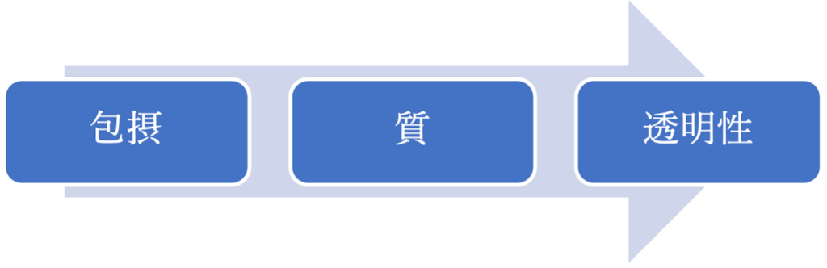

図2. OSを実装するうえで核となる価値：提案された方向性（図1に示された方向性を反転させたもの）

[^1]: *Cambridge English Dictionary* を参考にした。
[^2]: 初期のプラグマティスとやフェミニスト哲学者による研究にもとづき、探究の特定の状況に関連して調査の「文脈」を定義することの重要性については Leonelli (2016) を参照のこと。
[^3]: バーンズは「実践」という用語の定義を提示しており、これはチャンによる分析と私自身の用語の使い方をうまく補完するものである。”それらを実現するために常に相互に調整し整合性を維持することに関係する諸個人の集合的な成果” (Barnes 2001, 33)。
[^4]: レパートリーはプロジェクトを実施するために必要なスキル・概念・道具・資材・戦略・戦略・構造など、さまざまな要素から構成される。需要なのは、レパートリー内でこれら諸要素が共存していることではなく、むしろ研究者のパフォーマンス、つまり研究者が考え行動する仕方の骨組みを形づくるうえで、これらの要素が果たす役割についてである。この点については次章で述べたい。
[^5]: コリンズの知的変容に関する記念碑的な研究でも同様に、ある諸個人がほかの諸個人よりも多くの牽引力をえる理由のひとつとして「限られた注目空間」があげられている（Collins 1998）。
[^6]: 次も参照のこと。Intemann (2020)、「累積的優位」についてはRoss-Hellauer et al. (2022)。
[^7]: 共通の議題へ収束させることは往々にして境界戦略の重要な要素となるが、その他の諸要因（たとえば具体的な評価手法について合意すること）もまた境界設定を基礎づけ、認識論的活動の一貫性を確保することができるため、必要ない場合もあることに留意されたい。
[^8]: 私は、過度の専門化が一般的基準を考案し実装することを不可能にしている、あるいは望ましくないものにしていると主張しているのではない。むしろ、そのような諸々の基準と状況に埋め込まれた実践との間の避けられない緊張関係を定期的に検証する必要があり、その結果、両者で改定がなされることもあるということだ。
[^9]: 実践の諸システムが、（奇妙なものであろうが正当化されるものであろうが何にせよ）どのような批判でも反応すべきだという意味でもない。気候変動やワクチン接種など、ある目的の手段として利用されるような事例であっても、真剣にコミュニケーションおよび相互理解を図る試みがなされている限り、批判にある程度向き合うことは生産的だといえる。ここではパブリックエンゲージメントや「サイエンスウォーズ」に関する進行中の議論には取り組めない。関連文献としてDe Melo-Martín and Intemann (2018) をあげておく。またOSに関してはElliott and Resnik（2019）を参照のこと。
[^10]: オノラ・オニール、そしてのちにC・ティ・グエンは、透明性と信頼の間には避けられないトレードオフがあると主張していた。透明性を求めると欺瞞が誘発され最終的には関係者間で信頼が失われる傾向があり（O’Neill 2002）、つまり文脈依存性や主観性を認めない監視体制を生じさせるという（Nguyen 2021）。私はそうではなく、信頼と透明性の関係は文脈に依存すると考える。ある資源は開示するが他の資源は秘匿するという透明性に対する戦略的なアプローチは、信頼を高めるのに大いに役立つ。しかしこれは、そうした選択に関与する機関や集団に対する全般的な信頼性と、多数の人々に対して諸々の選択が正当なものであることを示す取り組みに依存する。道徳的に破綻した政府でも、どのデータを誰に公開するかということについては賢明な判断をくだすことができるが、それでも広くは信頼されないだろう。一方で、評判の良い企業が不適切にもセンシティブなデータの公開を選択するかもしれないが、そうした判断を明確に正当化するのに時間がかかる場合は特に、ほかの理由でえていた信頼から恩恵を受けることができる。